# Hands-on Time Series Analysis with R

Chapter 3: The Time Series Object

```r
library(knitr)
library(data.table)
library(Quandl)
library(TSstudio)
library(RplotterPkg)
library(RtsaPkg)
current_dir <- here::here("Hands-on Time Series Analysis with R")
```

Author: Rick Dean

Article date: 2020-12-25

Abstract

The following notes/scripts/plots are inspired by chapter 3 of the book [Hands-on Time Series Analysis with R](https://github.com/PacktPublishing/Hands-On-Time-Series-Analysis-with-R) by Rami Krispin

# 3 The Time Series Object

## 3.1 The Natural Gas Consumption dataset

Set the Quandl API key:

```r
Quandl.api_key(RtsaPkg::read_quandl_key())
```

Load the “FRED” data:

```r
NGC_ts <- Quandl(
  code = "FRED/NATURALGAS",
  collapse = "quarterly",
  type = "ts",
  end_date = "2018-12-31")
```

The class and structure of *NGC*:

```r
class(NGC_ts)
```

```
## [1] "ts"
```

```r
str(NGC_ts)
```

```
##  Time-Series [1:76] from 2000 to 2019: 2051 1513 1475 2588 2247 ...
```

Convert *NGC* to a data frame:

```r
NGC_dt <- RtsaPkg::ts_to_df(NGC_ts, col_name = "GasConsump")
str(NGC_dt)
```

```
## Classes 'data.table' and 'data.frame':   76 obs. of  2 variables:
##  $ GasConsump: num  2051 1513 1475 2588 2247 ...
##  $ DateTime  : Date, format: "2000-01-01" "2000-03-23" ...
##  - attr(*, ".internal.selfref")=<externalptr>
```

Plot *NGC*:

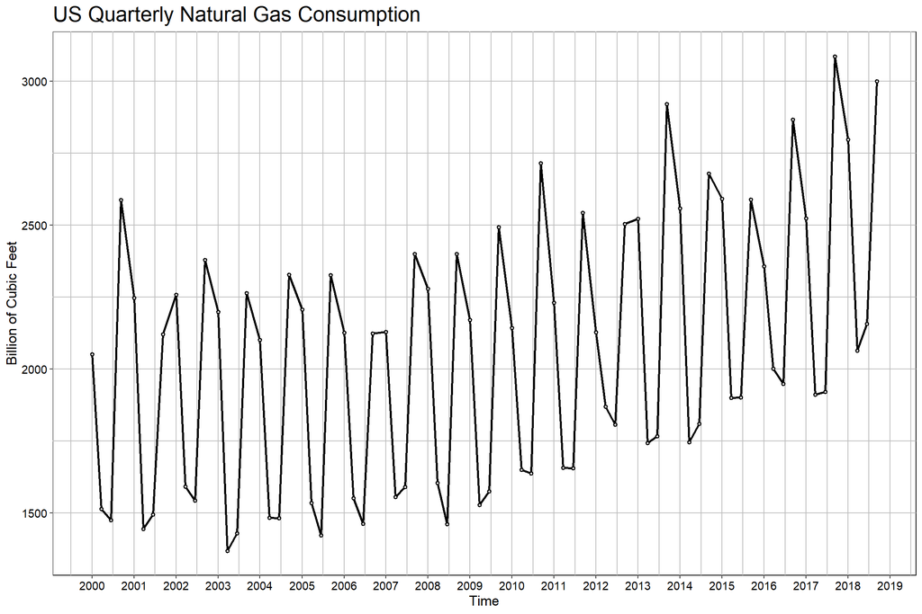

```r
RplotterPkg::create_scatter_plot(
  df = NGC_dt,
  aes_x = "DateTime",
  aes_y = "GasConsump",
  x_major_date_breaks = "1 year",
  x_date_labels = "%Y",
  connect = TRUE,
  title = "US Quarterly Natural Gas Consumption",
  x_title = "Time",
  y_title = "Billion of Cubic Feet",
  rot_y_tic_label = TRUE
)
```

## 3.2 The attributes of the *ts* class

A “ts” object is composed of two elements–the series values and its corresponding timestamp. It has several attributes such as the series, cycle, frequency, and the time interval between each consecutive observation. We can get the length of “ts” object and apply `head()` to get the values:

```r
length(NGC_ts)
```

```
## [1] 76
```

```r
head(NGC_ts, n = 32)
```

```
##  [1] 2050.6 1513.1 1475.0 2587.5 2246.6 1444.4 1494.1 2120.2 2258.4 1591.4
## [11] 1542.2 2378.9 2197.9 1368.4 1428.6 2263.7 2100.9 1483.7 1482.2 2327.7
## [21] 2205.8 1534.1 1422.5 2326.4 2126.4 1550.9 1462.1 2122.8 2128.8 1555.2
## [31] 1590.5 2399.2
```

For the NGC dataset, each calendar year is a full cycle and the quarters are the cycle units. By using `stats::cycle()` and `time()` we can see the cycles and time:

```r
head(stats::cycle(NGC_ts), 32)
```

```
##  [1] 1 2 3 4 1 2 3 4 1 2 3 4 1 2 3 4 1 2 3 4 1 2 3 4 1 2 3 4 1 2 3 4
```

```r
head(stats::time(NGC_ts), 32)
```

```
##  [1] 2000.00 2000.25 2000.50 2000.75 2001.00 2001.25 2001.50 2001.75 2002.00
## [10] 2002.25 2002.50 2002.75 2003.00 2003.25 2003.50 2003.75 2004.00 2004.25
## [19] 2004.50 2004.75 2005.00 2005.25 2005.50 2005.75 2006.00 2006.25 2006.50
## [28] 2006.75 2007.00 2007.25 2007.50 2007.75
```

The timestamp is a decimal number that is aligned with the cycles of the series. The values on the left hand side of the decimal point represent the cycle number (i.e. calendar year) and the values on the right side represent the cycle units.

Getting the series frequency and time interval between the observations:

```r
stats::frequency(NGC_ts)
```

```
## [1] 4
```

```r
stats::deltat(NGC_ts)
```

```
## [1] 0.25
```

Using the `stats::start()` and `stats::end()` functions:

```r
stats::start(NGC_ts)
```

```
## [1] 2000    1
```

```r
stats::end(NGC_ts)
```

```
## [1] 2018    4
```

### 3.2.1 Multivariate time series objects

The multiple time series object (class: “mts”) is a combination of “ts” and “matrix” classes. An example of a “mts” object is the `TSstudio::Coffe_Prices` dataset - monthly prices (USD per kg) between 1960 and 2018:

```r
data(Coffee_Prices)
RtsaPkg::get_series_info(Coffee_Prices)
```

```
## 'Coffee_Prices' series is a mts object with:
##  Variables: 2
##  Observations: 701
##  Frequency: 12
##  Start time: 1960 1
##  End time: 2018 5
## 'Coffee_Prices' Starting observations:
```

```
##        Robusta Arabica
## [1,] 0.6968643  0.9409
## [2,] 0.6887074  0.9469
## [3,] 0.6887074  0.9281
## [4,] 0.6845187  0.9303
## [5,] 0.6906915  0.9200
```

```r
class(Coffee_Prices)
```

```
## [1] "mts"    "ts"     "matrix"
```

Using *ts* functions on *mts* :

```r
stats::frequency(Coffee_Prices)
```

```
## [1] 12
```

```r
stats::deltat(Coffee_Prices)
```

```
## [1] 0.08333333
```

```r
head(stats::time(Coffee_Prices))
```

```
## [1] 1960.000 1960.083 1960.167 1960.250 1960.333 1960.417
```

```r
head(stats::cycle(Coffee_Prices))
```

```
## [1] 1 2 3 4 5 6
```

```r
stats::start(Coffee_Prices)
```

```
## [1] 1960    1
```

```r
stats::end(Coffee_Prices)
```

```
## [1] 2018    5
```

Converting an “mts” object to a data frame:

```r
Coffee_Prices_dt <- RtsaPkg::ts_to_df(Coffee_Prices)
str(Coffee_Prices_dt)
```

```
## Classes 'data.table' and 'data.frame':   701 obs. of  3 variables:
##  $ Robusta : num  0.697 0.689 0.689 0.685 0.691 ...
##  $ Arabica : num  0.941 0.947 0.928 0.93 0.92 ...
##  $ DateTime: Date, format: "1960-01-01" "1960-01-28" ...
##  - attr(*, ".internal.selfref")=<externalptr>
```

Prerequisities for merging two “ts” into “mts”: 1. Inputs are regular time series 2. Inputs have exactly same frequency or time interval between observations 3. Inputs start at same cycle number and cycle unit

### 3.2.2 Creating a “ts” object

The `stats::ts()` function allows creating a “ts” object. Example– create a monthly series with values from 1 to 60 beginning on January 2010. Frequency = 12 Cycle = a year with frequency units of months Start = frequency unit 1 (January) with cycle unit 2010 End = frequency unit 12 (December) with cycle unit 2014

```r
my_ts_1 <- stats::ts(
  data = 1:60, # series values
  start = c(2010,1), # time of the first observation
  end = c(2014,12), # time of the last observation
  frequency = 12 # the series frequency
)
RtsaPkg::get_series_info(my_ts_1)
```

```
## 'my_ts_1' series is a ts object with:
##  Variables: 1
##  Observations: 60
##  Frequency: 12
##  Start time: 2010 1
##  End time: 2014 12
## 'my_ts_1' Starting observations:
```

```
## [1] 1 2 3 4 5
```

Task: Convert a “data.frame” object (`TSstudio::US_indicators`) to a “ts” object.

```r
data(US_indicators)
str(US_indicators)
```

```
## 'data.frame':    528 obs. of  3 variables:
##  $ Date             : Date, format: "1976-01-31" "1976-02-29" ...
##  $ Vehicle Sales    : num  885 995 1244 1191 1203 ...
##  $ Unemployment Rate: num  8.8 8.7 8.1 7.4 6.8 8 7.8 7.6 7.4 7.2 ...
```

Convert the *Vehicle Sales* data.frame into a “ts” object package:

Since the input series is monthly we need to define the cycle(year) and frequency(month) units of the first observation. `start = c(1976, 1)`. We can define a “ts” object by defining the data, the start point and the frequency:

```r
total_vec_sales_ts <- ts(
  data = US_indicators$`Vehicle Sales`,
  start = c(1976, 1),
  frequency = 12
)
RtsaPkg::get_series_info(total_vec_sales_ts)
```

```
## 'total_vec_sales_ts' series is a ts object with:
##  Variables: 1
##  Observations: 528
##  Frequency: 12
##  Start time: 1976 1
##  End time: 2019 12
## 'total_vec_sales_ts' Starting observations:
```

```
## [1]  885.2  994.7 1243.6 1191.2 1203.2
```

```r
tail(stats::time(total_vec_sales_ts))
```

```
## [1] 2019.500 2019.583 2019.667 2019.750 2019.833 2019.917
```

Main limitations of “ts” is that it does not support multiple cycles such as a daily time series which can have both weekdays and yearly cycles. Also cannot retrieve original time stamp if is made up more than two elements. In `total_vec_sales_ts` the day component is lost.

### 3.2.3 Creating a *mts* object

Task: Join both vehicle sales and unemployment rate series’ from *US_indicators* into an “mts” object.

1. Review the data.frame:

```r
str(US_indicators)
```

```
## 'data.frame':    528 obs. of  3 variables:
##  $ Date             : Date, format: "1976-01-31" "1976-02-29" ...
##  $ Vehicle Sales    : num  885 995 1244 1191 1203 ...
##  $ Unemployment Rate: num  8.8 8.7 8.1 7.4 6.8 8 7.8 7.6 7.4 7.2 ...
```

2. Set the *data*, *start*, and *frequency* as we did above:

```r
US_indicators_mts <- ts(
  data = US_indicators[, c("Vehicle Sales", "Unemployment Rate")],
  start = c(1976, 1),
  frequency = 12
)
RtsaPkg::get_series_info(US_indicators_mts)
```

```
## 'US_indicators_mts' series is a mts object with:
##  Variables: 2
##  Observations: 528
##  Frequency: 12
##  Start time: 1976 1
##  End time: 2019 12
## 'US_indicators_mts' Starting observations:
```

```
##      Vehicle Sales Unemployment Rate
## [1,]         885.2               8.8
## [2,]         994.7               8.7
## [3,]        1243.6               8.1
## [4,]        1191.2               7.4
## [5,]        1203.2               6.8
```

### 3.2.4 Setting the series frequency

Calculation of series freqency can be divided into two groups: * a daily frequency derived from the number of days in calendar year (weeks, hours, minutes in year) * any other frequency not derived from number of days

Create a data.frame with daily time over 10 years:

```r
daily_dt <- data.table::data.table(
  date = seq.Date(as.Date("2010-01-01"), length.out = 365 * 10, by = "day"),
  y = rnorm(365 * 10, mean = 15, sd = 2)
)
str(daily_dt)
```

```
## Classes 'data.table' and 'data.frame':   3650 obs. of  2 variables:
##  $ date: Date, format: "2010-01-01" "2010-01-02" ...
##  $ y   : num  12 16.5 16.3 16.1 12.6 ...
##  - attr(*, ".internal.selfref")=<externalptr>
```

We want to create “ts” object with a weekly cycle which suggests a frequency of the series to be set to 7:

```r
days_week_ts <- ts(
  data = daily_dt$y,
  start = c(1, lubridate::wday(min(daily_dt$date))),
  frequency = 7
)
RtsaPkg::get_series_info(days_week_ts)
```

```
## 'days_week_ts' series is a ts object with:
##  Variables: 1
##  Observations: 3650
##  Frequency: 7
##  Start time: 1 6
##  End time: 523 1
## 'days_week_ts' Starting observations:
```

```
## [1] 11.99459 16.48205 16.29493 16.13998 12.57898
```

For a yearly cycle of the daily series we would set the frequency to 365 (ignoring leap year):

```r
days_year_ts <- ts(
  data = daily_dt$y,
  start = c(2010, lubridate::yday(min(daily_dt$date))),
  frequency = 365
)
RtsaPkg::get_series_info(days_year_ts)
```

```
## 'days_year_ts' series is a ts object with:
##  Variables: 1
##  Observations: 3650
##  Frequency: 365
##  Start time: 2010 1
##  End time: 2019 365
## 'days_year_ts' Starting observations:
```

```
## [1] 11.99459 16.48205 16.29493 16.13998 12.57898
```

Setting the frequency to 365.25 to smooth the effect of leap year:

```r
days_year_leap_ts <- ts(
  data = daily_dt$y,
  start = c(2010, lubridate::yday(min(daily_dt$date))),
  frequency = 365.25
)
RtsaPkg::get_series_info(days_year_leap_ts)
```

```
## 'days_year_leap_ts' series is a ts object with:
##  Variables: 1
##  Observations: 3650
##  Frequency: 365.25
##  Start time: 2010
##  End time: 2019.99041752225
## 'days_year_leap_ts' Starting observations:
```

```
## [1] 11.99459 16.48205 16.29493 16.13998 12.57898
```

## 3.3 Data manipulation of ts objects

### 3.3.1 The window function

The `stats::window()` function subsets a “ts” object based on a time range. Use the function to extract the observations of the year 2005 from the NGC series:

```r
RtsaPkg::get_series_info(NGC_ts)
```

```
## 'NGC_ts' series is a ts object with:
##  Variables: 1
##  Observations: 76
##  Frequency: 4
##  Start time: 2000 1
##  End time: 2018 4
## 'NGC_ts' Starting observations:
```

```
## [1] 2050.6 1513.1 1475.0 2587.5 2246.6
```

```r
window_2005_ts <- stats::window(
  x = NGC_ts,
  start = c(2005,1),
  end = c(2005,4)
)
window_2005_ts
```

```
##        Qtr1   Qtr2   Qtr3   Qtr4
## 2005 2205.8 1534.1 1422.5 2326.4
```

Can get a specific frequency unit from the series. Extract all the observations of the series that occurred in the third quarter of the year:

```r
window_3q_ts <- stats::window(
  x = NGC_ts,
  start = c(2000, 3),
  frequency = 1
)
window_3q_ts
```

```
## Time Series:
## Start = 2000.5
## End = 2018.5
## Frequency = 1
##  [1] 1475.0 1494.1 1542.2 1428.6 1482.2 1422.5 1462.1 1590.5 1460.9 1575.0
## [11] 1637.5 1655.6 1807.2 1767.0 1809.3 1901.3 1947.8 1920.5 2156.1
```

Note: a frequency = 1 sets the output to a yearly series

```r
str(window_3q_ts)
```

```
##  Time-Series [1:19] from 2000 to 2018: 1475 1494 1542 1429 1482 ...
```

### 3.3.2 Aggregating ts objects

The `stats::aggregate()` function is a generic function for aggregating “ts” and “data.frame” objects. Use the aggregate “sum” to transform the NGC series from a quarterly to yearly:

```r
NGC_year_ts <- stats::aggregate(NGC_ts, nfrequency = 1, FUN = "sum")
NGC_year_ts
```

```
## Time Series:
## Start = 2000
## End = 2018
## Frequency = 1
##  [1]  7626.2  7305.3  7770.9  7258.6  7394.5  7488.8  7262.2  7673.7  7743.0
## [10]  7765.4  8144.0  8085.3  8307.3  8951.8  8791.8  8980.7  9171.1  9440.2
## [19] 10015.4
```

### 3.3.3 Creating lags and leads for ts objects

The `stats::lag()` and `stats::lead()`can be used to create lags and leads. Create a seasonal lag of NGC_ts:

```r
NGC_lag4_ts <- stats::lag(NGC_ts, k = -4)
RtsaPkg::get_series_info(NGC_lag4_ts)
```

```
## 'NGC_lag4_ts' series is a ts object with:
##  Variables: 1
##  Observations: 76
##  Frequency: 4
##  Start time: 2001 1
##  End time: 2019 4
## 'NGC_lag4_ts' Starting observations:
```

```
## [1] 2050.6 1513.1 1475.0 2587.5 2246.6
```

The first quarter of 2001 is the lag of the corresponding quarter in 2000.

## 3.4 Visualizing ts and mts objects